# Operators

## Operators

Operators are used to combine values. Java has rich set of arithmetic operators and logical functions.

### Arithmetic operators

The usual arithmetic operators `+, -, *, /` are used in Java for addition, substraction, multiplication, division. The `/` operator denotes integer division if both values are integers and floating point division otherwise. Integer remainder is denoted by `%` operator.

```java
5 / 2
```

```
2
```

```java
5.0 / 2
```

```
2.5
```

```java
5 % 2
```

```
1
```

```java
5.0 % 2.0
```

```
1.0
```

*Note that integer division by zero raises an exception, while a floating-point division by 0 yields NaN or Infinity*

```java
5 / 0
```

```
---------------------------------------------------------------------------
java.lang.ArithmeticException: / by zero
	at .(#16:1)
```

```java
5.0 / 0
```

```
Infinity
```

```java
- 5.0 / 0
```

```
-Infinity
```

```java
0 / 0.0
```

```
NaN
```

### Mathematical Functions

The `Math` class contains a lot of mathematical functions thay you may need. To take square root of a number use `Math.sqrt()` method. First of all, you need to import this class using the keyword `import`.

```java
import java.lang.Math;

double x = 4;
double y = Math.sqrt(x);
System.out.println(y);
```

```
2.0
```

To find the power of some number use `Math.pow()` function.

```java
double a = Math.pow(2, 5); // 2 in extent of 5
System.out.println(a);
```

```
32.0
```

Math.pow() takes 2 double parameters and returns double as a result.

A Math class also supplies the usual trigonometric functions: Math.sin, Math.cos, Math.tan, Math.atan, Math.atan2

### Conversion between numeric types

It is often necessary to convert one type to another. Legal convertion between types:

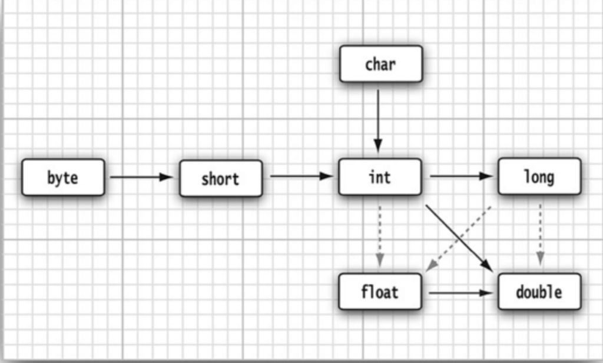

The six solid arrow denote conversions without information losses. The three dotted arrows denote conversions that may lead to information losses.

```java
int a = 123456789;
float f = a;
System.out.println(f);
```

```
1.23456792E8
```

A large integer 123456789 has more digits than float can represent. When converting from this int to float we lose some precision.

When we do some calculation with different type, both operands are converted to a common type before calculation. If one of the operands is double, the other one will be converted to double. If one of the operands is float, the other one will be converted to float. If one the the operands if long, the other one will be converted to long. Otherwise both operands will be converted to int.

```java
byte a = 1;
byte b = 2;
byte c = a + b;
```

```
|   byte c = a + b;
incompatible types: possible lossy conversion from int to byte
```

```java
int c = a + b;
c
```

```
3
```

```java
int a = 5;
double b = 10;
var c = a + b;
c
```

```
15.0
```

### Casts

You saw that int values are automatically converted to double when necessary. Numeric conversions are possible in Java, but some information can be lost. Conversions in which information may be lost are done by means of *casts*.

```java
double d = 9.9999;
int i = (int) d;
i
```

```
9
```

```java
d = i;
d
```

```
9.0
```

If you want to round floating point numbers to the nearest integer, use `Math.round()` method:

```java
double d = 9.9999;
int i =(int) Math.round(d);
i
```

```
10
```

You still need use a cast after Math.round call, because it returns long value.

You cannot cast between boolean value and numeric types. This conversion prevents common errors. In case you do want to convert boolean to numeric type - use expression: `isTrue ? 1 : 0;`

```java
boolean isSunny = true;
int isSunnyInt = isSunny ? 1 : 0;
System.out.println(isSunnyInt);
```

```
1
```

### Combining assignment with operators

There is a convenient shortcut for asignment operations:

```java
int x = 4;
x += 1; // equivalent of x = x + 1;
x
```

```
5
```

Also you can use *=, /=, -=, %=

### Increment and decrement operators

You can add or substruct one to(from) a number with the following shortcut:

```java
a = 2;
a++; // a = a + 1
a
```

```
3
```

```java
int b = 4;
b--;
b
```

```
3
```

This cannot be applied to numbers themselves. For example, 4++ is not a legal expression.  
There are two form of increment operator: *postfix* and *prefix*.

```java
int a = 4;
System.out.println(a++); // 4
System.out.println(a); // 5
System.out.println(a--); // 5
System.out.println(a); // 4
System.out.println(--a); // 3
System.out.println(++a); // 4
```

```
4
5
5
4
3
4
```

### Relational and boolean operators

Java has a full set of relational operators. To test two numbers for equality, use the double equal sign, ==.

```java
3 == 7
```

```
false
```

```java
3 == 3
```

```
true
```

Use != for inequality.

```java
3 != 7;
```

```
true
```

Finally, you have standard >, <, <=, >= operators(greater than, less than, less than or equal, greater than or equal.

Logical *AND* operator is Java uses `&&` sign and `||` for logical *OR*.

```java
a = 5;
b = 7;
c = 7;
System.out.println("a > b -> " + (a > b));
System.out.println("a < b -> " + (a < b));
System.out.println("c >= b -> " + (c >= b));
System.out.println("a <= b -> " + (a <= b));
```

```
a > b -> false
a < b -> true
c >= b -> true
a <= b -> true
```

```java
true && true // 1 * 1 = 1
```

```
true
```

```java
true && false // 1 * 0 = 0
```

```
false
```

```java
true || true // 1 + 1 = 2
```

```
true
```

```java
true || false // 1 + 0 = 1
```

```
true
```

```java
true || false && true // 1 + (0 * 1) = 1
```

```
true
```

```java
true || false && false // 1 + 0 * 0 = 1
```

```
true
```

```java
(true || false) && false // (1 + 0) * 0 = 0
```

```
false
```

```java
int x = 0;

if (x != 0 && 10 / x > 2) {
    // do smth
} else {
    System.out.println("Else block");
}
```

```
Else block
```

```java
int x = 0;

if (x != 0 || 10 / x > 2) {
    // do smth
} else {
    System.out.println("Else block");
}
```

```
---------------------------------------------------------------------------
java.lang.ArithmeticException: / by zero
	at .(#168:1)
```

#### Ternary operator

```java
int a = 143;
int b = 113;

int min = (a < b) ? a : b;
min
```

```
113
```

#### Bitwise operators for self education

### Operators precedence

| Operator | Associativity |
| --- | --- |
| [] . () method call | Left to right |
| ! ~ ++ -- +(unary) -(unary) () (cast) new | Right to left |
| * / % | Left to right |
| + - | Left to right |
| << >> >>> | Left to right |
| < <= > >= instanceof | Left to right |
| == != | Left to right |
| & | Left to right |
| ^ | Left to right |
| \| | Left to right |
| && | Left to right |
| \|\| | Left to right |
| = += -= *= /= %= ... | Right to left |

```java
2 + 3 * 4 / 5 % 2 - 10
```

```
-8
```

```java
Integer.MAX_VALUE + 1
```

```
-2147483648
```

```java
Integer.MAX_VALUE
```

```
2147483647
```

```java
String a = Integer.toBinaryString(Integer.MAX_VALUE);
a
```

```
1111111111111111111111111111111
```

```java
String b = Integer.toBinaryString(10);
b
```

```
1010
```

```java
String b = Integer.toBinaryString(Integer.MAX_VALUE + 1);
b
```

```
10000000000000000000000000000000
```

```java
int c = Integer.MAX_VALUE;
System.out.println(c >> 1);
System.out.println(c / 2);
c
```

```
1073741823
1073741823
```

```
2147483647
```